# Informe Técnico: Indicadores Socioeconómicos de EE.UU.

Valeria Mora

2025-08-27

#Tabla de indicadores clave

```r
# Cargar base depurada
data_clean <- read_csv("Base_de_datos_depurada.csv") %>%
  rename(
    label = 1,
    estimate = 2,
    percent = 4
  ) %>%
  mutate(
    estimate = as.numeric(gsub(",", "", estimate)),
    percent = as.numeric(gsub("%", "", percent))
  )

# Filtrar indicadores
indicadores <- data_clean %>%
  filter(label %in% c(
    "Population 16 years and over",
    "In labor force",
    "Employed",
    "Unemployed",
    "Median household income (dollars)"
  )) %>%
  select(label, estimate, percent)

kable(indicadores, caption = "Tabla 1. Indicadores clave de población y economía")
```

Tabla 1. Indicadores clave de población y economía

| label | estimate | percent |
| --- | --- | --- |
| Population 16 years and over | 271122729 | NA |
| In labor force | 173038795 | 63.8 |
| Employed | 164346993 | 60.6 |
| Unemployed | 7395929 | 2.7 |
| In labor force | 81979611 | 59.4 |
| Employed | 78266177 | 56.7 |
| Median household income (dollars) | 77719 | NA |

#Gráfico de fuerza laboral

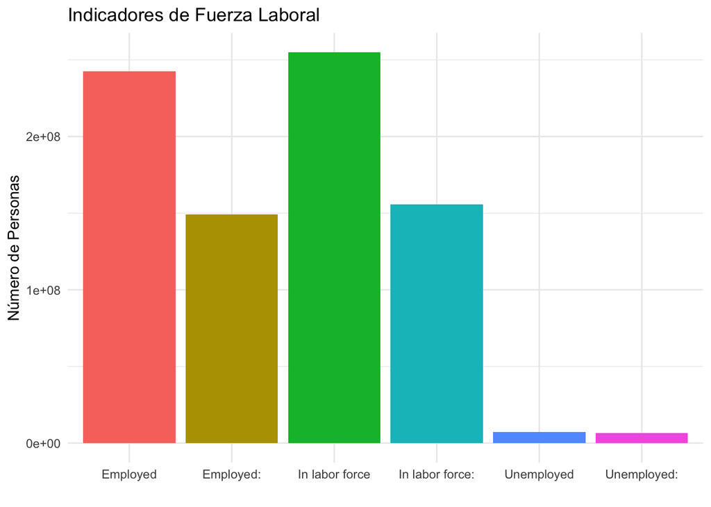

```r
fig_labor <- data_clean %>%
  filter(str_detect(label, "In labor force|Employed|Unemployed"))

ggplot(fig_labor, aes(x = label, y = estimate, fill = label)) +
  geom_bar(stat = "identity") +
  labs(title = "Indicadores de Fuerza Laboral",
       x = "",
       y = "Número de Personas") +
  theme_minimal() +
  theme(legend.position = "none")
```

#Gráfico de pobreza aproximada

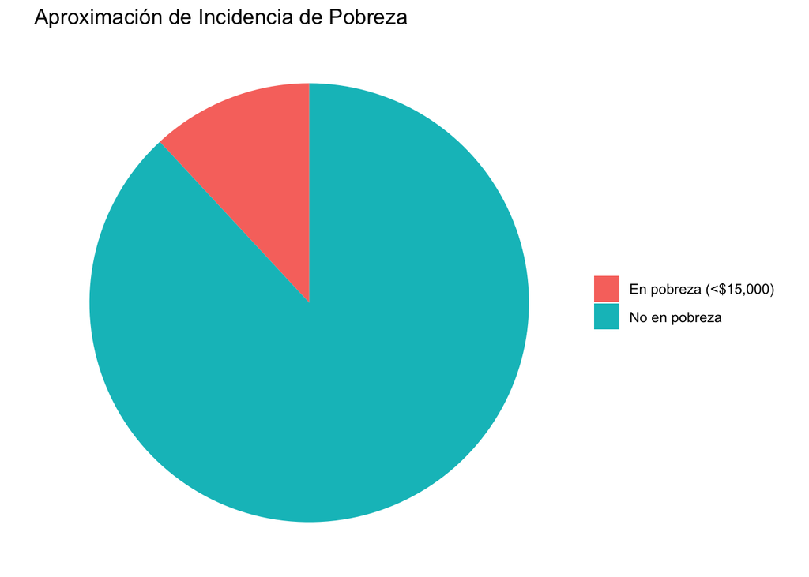

```r
total_hogares <- data_clean %>% filter(label == "Total households") %>% pull(estimate)

hogares_bajo_15000 <- data_clean %>%
  filter(label %in% c("Less than $10,000", "$10,000 to $14,999")) %>%
  summarise(total = sum(estimate, na.rm=TRUE)) %>%
  pull(total)

pct_bajo_15000 <- round(hogares_bajo_15000 / total_hogares * 100, 1)
pct_encima_15000 <- 100 - pct_bajo_15000

ggplot(data.frame(
  grupo = c("En pobreza (<$15,000)", "No en pobreza"),
  valor = c(pct_bajo_15000, pct_encima_15000)
), aes(x="", y=valor, fill=grupo)) +
  geom_bar(stat="identity", width=1) +
  coord_polar(theta="y") +
  labs(title="Aproximación de Incidencia de Pobreza") +
  theme_void() +
  theme(legend.title=element_blank())
```

# Gráfico 1: Indicadores de Fuerza Laboral

Este gráfico de barras representa distintos indicadores del mercado laboral:

**Interpretación:**  
- La mayoría de la población en edad laboral está empleada.  
- El desempleo es bajo en términos relativos (~2.7%, como se muestra en la tabla).

# Gráfico 2: Aproximación de Incidencia de Pobreza

Este gráfico de pastel muestra la proporción de personas según su nivel de ingresos:

**Datos principales:**  
- **En pobreza (<$15,000):** Representan aproximadamente 11.9% de los hogares.  
- **No en pobreza:** La mayoría tiene ingresos por encima del umbral de pobreza (88.1%).

**Interpretación:**  
- Aunque hay personas en situación de pobreza, la mayoría de la población no se encuentra en pobreza extrema.  
- Esto se relaciona con el ingreso mediano del hogar, que es de $77,719, lo cual es relativamente alto.  
- Permite identificar segmentos de población con menor capacidad económica y resalta desigualdades en ingresos.